# Actividades Recreativas de cada persona y su Rendimiento Académico

## *Importancia del Tema*

- Como **objetivo principal**, nuestro grupo busca determinar si las actividades recreativas, así como el tiempo empleado en ellas, influyen directamente a las personas en el ámbito académico. Consideramos que este estudio es sumamente importante, pues de corroborar que el impacto en los estudiantes es positivo, se podría concientizar a la población de la importancia del espacio de recreación y, paulatinamente, ver mejoras en este sector.
- Para lograr este objetivo, desarrollaremos otros puntos importantes, como lo son: reconocer las variables significativas de las muestras recolectadas, definirlas e indicar los patrones visibles entre estas.

## *Muestra representativa confiable*

Para conseguir una muestra representativa confiable, definimos como nuestra población a todos los alumnos de UTEC, esto porque queremos evaluar la relación entre las actividades recreativas y los estudios en la comunidad utecsina; como unidad muestral, nos enfocamos más a los alumnos que hayan ingresado a la universidad hasta el pasado ciclo regular, es decir, el ciclo 2020-2. Esto debido a que una de nuestras variables significativas es el promedio ponderado de cada alumno encuestado, por lo que si evaluamos a los alumnos ingresados en el presente ciclo, no nos servirán de mucho, ya que no cuentan con este dato.

Después de todo lo mencionado anteriormente, hemos concluido que el tipo de muestreo es muestreo por conveniencia, debido a que usaremos cada dato según lo que vamos a querer evaluar, además podremos encontrar comportamientos que tienen en común cada uno de los individuos y la relación que guardan entre sí.

## *Base de Datos*

Nuestra base de datos cuenta con 112 observaciones antes de la filtración de datos.

*Criterios para la filtración de base de datos:*

- Eliminamos observaciones con código 2021, esto debido a que no cuentan con la variable “promedio ponderado”, la cual es de suma importancia para nuestro estudio, pues es una variable significativa.
- Eliminamos variables que no eran necesarias para el estudio, como la variable marca temporal (que se creó al descargar los datos) , los correos institucionales y la variable “otro”.
- Cambiamos algunos datos faltantes por datos de igual significado. Ejemplo: Pusimos como variable la cantidad de horas que trabajan los encuestados por semana, esto solo nos serviría si marcan la opción de que trabajan, quienes no lo hacen, se les considera como si trabajaran 0 horas.
- Cambiamos el nombre de las variables para una mejor lectura de datos. Ejemplo: Edad (años) = Edad (Ejemplo: 18)

```r
#Cambiar nombre a las variables
DF %>% rename('Edad (años)'='Edad (Ejemplo: 18)', 'Promedio ponderado'='Promedio Ponderado (Ejemplo: 15.82)', 'Actividad recreativa'='Actividades recreativas que más realizas en tus tiempos libres', 'Cantidad de cursos en el semestre'='Número de cursos matriculados en el semestre 2021-1 (Ejemplo: 6)', 'Cantidad de horas de clases a la semana'='Cantidad de horas de clase por semana (Ejemplo: 22)', 'Cantidad de horas dedicadas al estudio a la semana'='Promedio de horas semanales dedicadas a estudiar (Externo al horario de clases)', 'Cantidad de horas dedicadas a las actividades recreativas'='Promedio de horas semanales dedicadas a tus actividades recreativas', 'Trabaja'='¿Trabajas?', 'Horas de trabajo'='En caso trabajes, ¿Cuántas horas trabajas por semana?', 'Importancia de realizar A.R.'='¿Cuán importante consideras realizar actividades recreativas?', 'Consideración de realizar A.R.'='¿Consideras que realizar actividades recreativas ayuda en tu rendimiento académico?', 'Ayuda por parte de las A.R.'='Si tu respuesta anterior fue sí, ¿en qué crees que te ayudan?')->DF
```

```r
b<- which(DF$`Cantidad de horas dedicadas a las actividades recreativas` == "3 horas")
DF$`Cantidad de horas dedicadas a las actividades recreativas`[b] <- 3

# Se pone el promedio de ambos valores que considerábamos como rangos
d<- which(DF$`Cantidad de horas dedicadas a las actividades recreativas` == "4-6")
DF$`Cantidad de horas dedicadas a las actividades recreativas`[d] <- 5

# Convertir la variable en númerica
DF$`Cantidad de horas dedicadas a las actividades recreativas` <- as.numeric(DF$`Cantidad de horas dedicadas a las actividades recreativas`)

# filtrar o limpiar datos mal ingresados
e<- which(DF$`Cantidad de horas de clases a la semana` == "14-18")
DF$`Cantidad de horas de clases a la semana`[e] <- 16

# Convertir la variable en númerica
DF$`Cantidad de horas de clases a la semana` <- as.numeric(DF$`Cantidad de horas de clases a la semana`)
```

En resumen con estos códigos hemos podido filtrar datos, eliminar variables u observaciones que no van con el estudio y convertir datos de las variables en numéricas.

Nuestra nueva data presenta:

Cantidad de datos faltantes:

```
## [1] 5
```

Observaciones completas:

```
## [1] 105
```

## *Variables*:

| Cantidad de variables | Cantidad de variables numéricas | Cantidad de variables categóricas | Significativas |
| --- | --- | --- | --- |
| 15 | 7 | 8 | 11 |

**Variables no significativas:**

-Código de alumno => Categórica ordinal  
-Edad(años) => Numérica discreta  
-Carrera de la UTEC => Categórica nominal  
-Importancia de realizar A.R. => Categórica nominal

**Variables significativas:**

-Orden de mérito => Categórica ordinal  
-Actividad recreativa => Categórica nominal  
-Consideración de realizar A.R. => Categórica nominal  
-Ayuda por parte de las A.R. => Categórica nominal  
-Trabaja => Categórica nominal

-Cantidad de cursos en el semestre => Numérica discreta  
-Promedio ponderado => Numérica continua  
-Cantidad de horas de clases a la semana => Numérica continua  
-Cantidad de horas dedicadas al estudio a la semana => Numérica continua  
-Cantidad de horas dedicadas a las actividades recreativas => Numérica continua  
-Horas de trabajo => Numérica continua

## *Análisis descriptivo*

Para este análisis, hemos decidio usar algunas de nuestras variables más significativas, pues son variables que nos serán de mucha ayuda más adelante durante la realización del análisis inferencial y predictivo.

### Promedio Ponderado:

- **Media:** Es usado para poder tener una idea clara sobre donde se encontraría el equilibrio de notas de nuestra muestra, este descriptor nos será muy útil durante nuestras pruebas de hipótesis.

```
## [1] 15.35
```

- **Mediana:** La mediana en este caso nos da en donde se encuentra la tendencia central de los promedios ponderados reales.

```
## [1] 15.33
```

- **Desviación estándar:** Nos permite saber que tan alejados se encuentran los datos reales de la media de los promedios ponderados.

```
## [1] 1.61
```

### Histograma del promedio ponderado: distribución normal

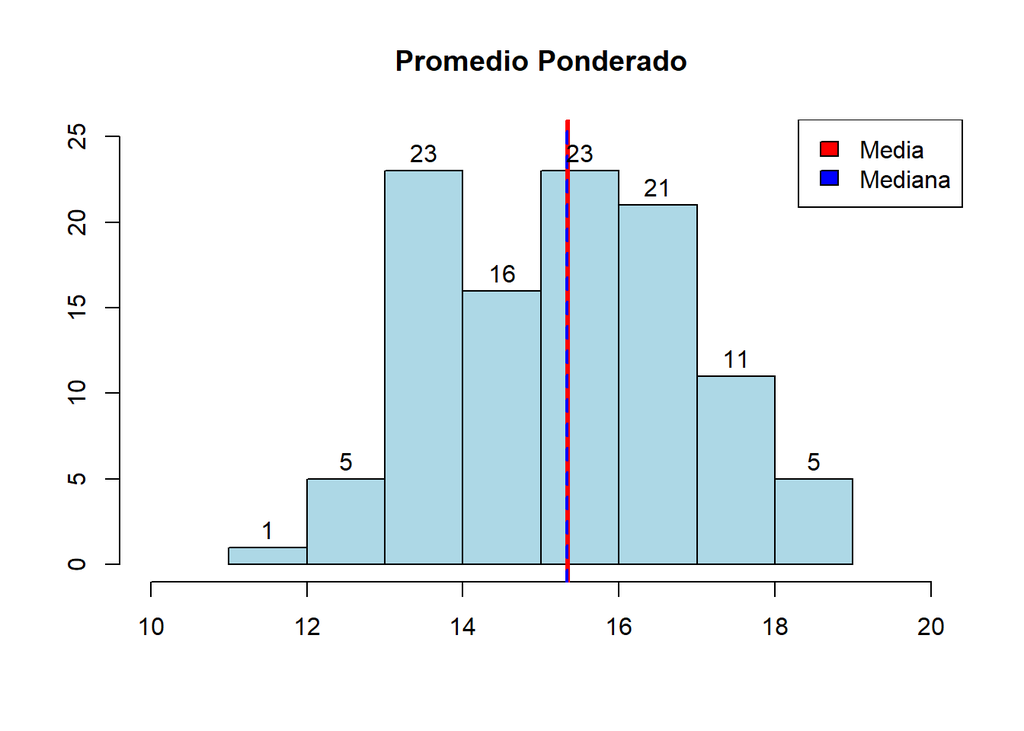

Al analizar el respectivo histograma de promedios ponderados, podemos observar que la mayor cantidad de personas tienen un promedio mayor a 15, además se distinguen tanto la media como la mediana de dicha variable, cuyas ubicaciones en la gráfica son coherentes con los descriptores numéricos hallados anteriormente, pues la media es ligeramente mayor a la mediana.

### Cantidad de Cursos en el semestre:

- **Media:** Es la cantidad promedio de cursos que llevan las personas encuestadas para nuestro estudio.

```
## [1] 5.45
```

- **Mediana:** Indica la tendencia central de los cursos que nuestra muestra lleva durante el ciclo, esta variable es de suma importancia debido a que es una de las escogidas para realizar nuestro análisis inferencial.

```
## [1] 5.5
```

- **Moda:** La cantidad de cursos que la mayoría de nuestros encuestados decidió llevar durante el semestre.

```
## [1] 5
```

### Caja de bigotes del número de cursos

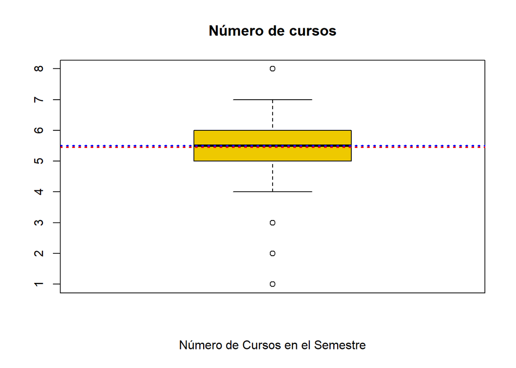

Se observa que los alumnos de nuestra muestra tienden a llevar entre 5 y 6 cursos durante el ciclo, lo cual se puede ver debido a la concentración de observaciones en este rango. Por otro lado, se observan algunos datos atípicos, uno de ellos representa la carga excesiva de cursos que lleva un alummno, cuyo número de materias es 8, por el contrario, se muestran 3 datos atípicos que indican la poca cantidad de cursos llevados durante el ciclo, los cuales van desde 1 a 3 cursos.

### Cantidad de horas dedicadas al estudio a la semana:

- **Media:** Nos da la información necesaria para saber la cantidad de horas promedio dedicadas a estudiar semanalmente de nuestra muestra.

```
## [1] 16.2
```

- **Mediana:** Nos muestra en cuanto está la tendencia central de horas dedicadas a los estudios por semana.

```
## [1] 11
```

- **Moda:** Brinda la cantidad de horas de estudio semanal más frecuente.

```
## [1] 10
```

### Caja de bigotes de cantidad de horas dedicadas al estudio a la semana

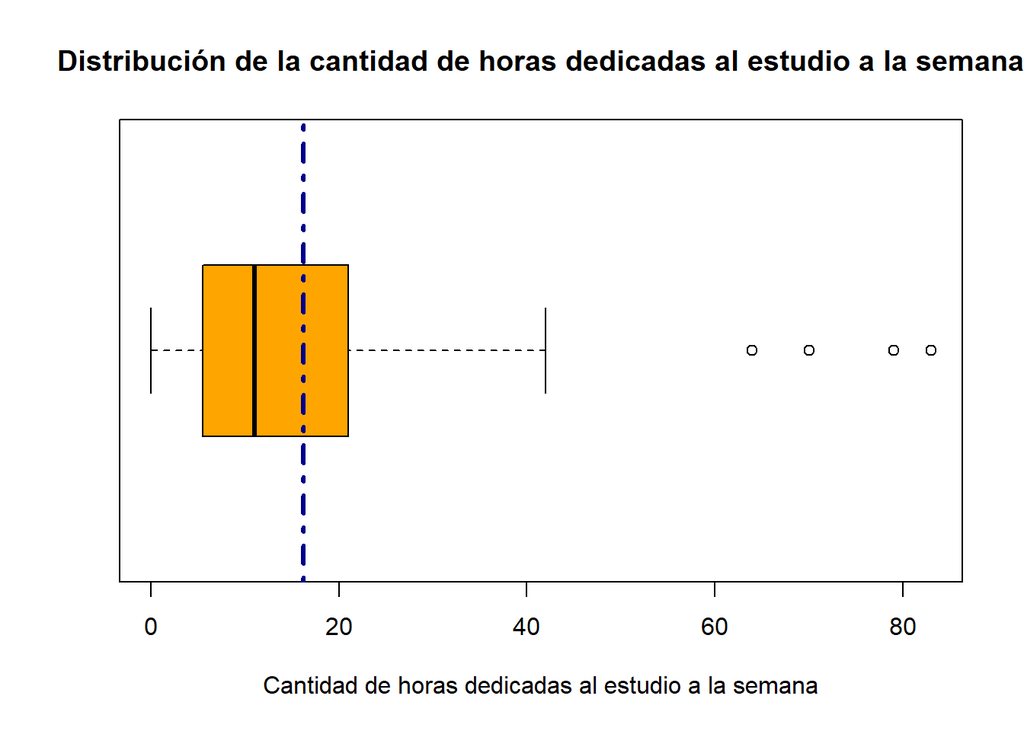

### Cantidad de horas dedicadas a las actividades recreativas:

- **Media:** Nos da la información necesaria para poder saber un aproximado de cuanto es la cantidad de horas promedio para que usan nuestros encuestados para recrearse.

```
## [1] 11.39
```

- **Mediana:** Nos muestra en que valor se encuentra la mayor tendrencia de horas dedicadas a la recreación de nuestra muestra.

```
## [1] 8
```

- **Moda:** Brinda cuantas horas es más frecuente dedicar a actividades recreativas.

```
## [1] 5
```

### Histograma de cantidad de horas dedicadas a las actividades recreativas: distribución geométrica

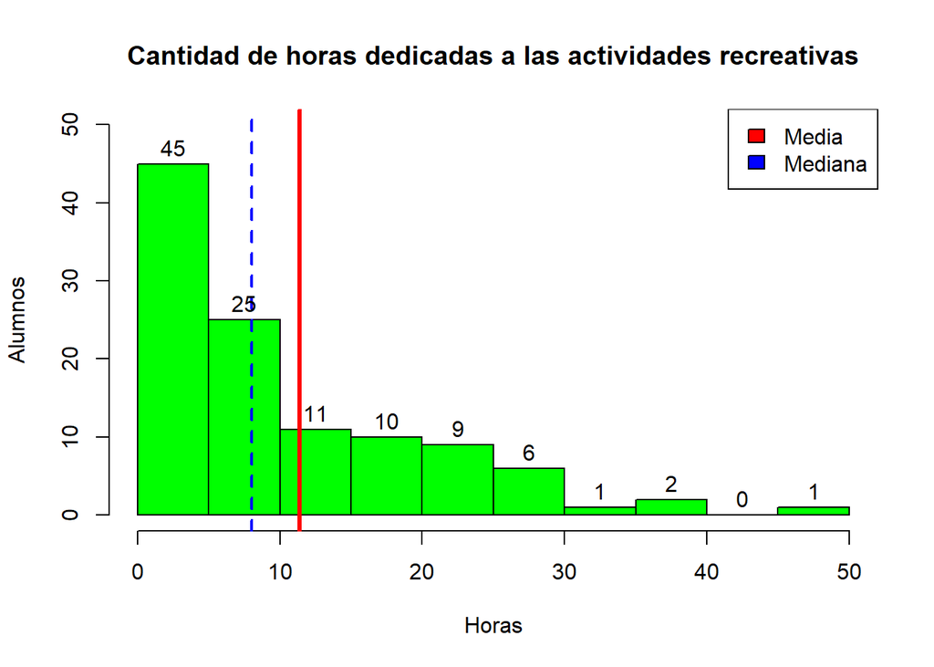

Podemos notar que hay un gran cúmulo de datos en la parte izquierda de nuestra gráfica, lo cual indica un sesgo hacia la derecha. Mediante esta gráfica podemos interpretar que la mayor cantidad de alumnos le dedica menos de 10 horas a recrearse o distraerse, lo cual según nuestro estudio, creemos que prodría darles algunas complicaciones, esto debido a la carga en sus estudios y el no tener mucho tiempo de relajo o distracción.

## *Análisis Inferencial*

### Parámetros de estudio

- Nivel de Confianza: *90%*
- Significancia: *10%*
- Tamaño de muestra:

```
## [1] 110
```

- Media del Promedio Ponderado:

```
## [1] 15.35
```

- En nuestro estudio, utilizaremos un intervalo de confianza del 90% debido a que, al contar con una muestra relativamente pequeña, la consideramos insuficiente para encontrar buenas correlaciones. Por lo mismo que mencionamos anteriormente, el tamaño de nuestra muestra no nos garantiza mucho éxito, por lo que la significancia usada es del 10%, es decir, habrá un 10% de probabilidades de rechazar la hipótesis nula planteada en nuestra pruebas. Además nuestra proyecto es muy subjetivo, por lo que no creemos que pueda haber una correlación fuerte y directa entre algunas de nuestras variables. Por eso mismo, creemos que un intervalo de confianza menor, nos ayudaría a encontrar indicios de tendencias que únicamente se presentarían de tener una muestra más grande, con la cual si podríamos usar un mayor nivel de confianza.
- Para nuestras pruebas de hipótesis, usaremos la media del promedio ponderado como $μ$, pues es nuestra variable más significativa, debido a que es la representación del rendimiento académico de nuestros encuestados, por lo cual, su estudio y comportamiento respecto a las demás variables será muy interesante de analizar.

### Primera prueba de Hipótesis:

$H_0:$ *Las personas que le dedican menos de 10 horas a sus actividades recreativas, tienen un promedio ponderado menor al de nuestra media muestral*

$H_1:$ *Las personas que le dedican menos de 10 horas a sus actividades recreativas, tienen un promedio ponderado mayor al de nuestra media muestral*

**Justificación:**

Se escogió esta prueba de hipótesis debido a que, necesitamos verificar si el tiempo que demandan nuestros encuestados en realizar sus actividades recreativas puede o no afectar a su rendimiento académico, pues creemos que mientras menos tiempo le dediquen a esto, podrían tener menos tiempo de relajar su mente, lo cual ocasionaría una baja en sus notas. Escogimos el promedio ponderado menor al de la media muestral, porque consideramos que es un número delimitador y lo tomaremos como punto de referencia para nuestro estudio.

**Desarrollo:**

- Datos Iniciales:

```r
a<-which(DF$`Cantidad de horas dedicadas a las actividades recreativas`<=10)
datos3<-DF[a,]
n<-nrow(datos3)
media<-mean(datos3$"Promedio ponderado", na.rm=TRUE ) #media muestral
valor<-mean(DF$`Promedio ponderado`, na.rm = TRUE)
sigma<-sd(datos3$"Promedio ponderado", na.rm = TRUE) #desv estandar muestral
```

- “Z Crítico”

```
## [1] 1.667239
```

```
## [1] 15.7596
```

```
## [1] 15.1097
```

- Prueba de hipótesis:

```
## [1] 0.4488
```

```
## [1] 0.3275
```

*Gráfica (Unilateral derecha):*

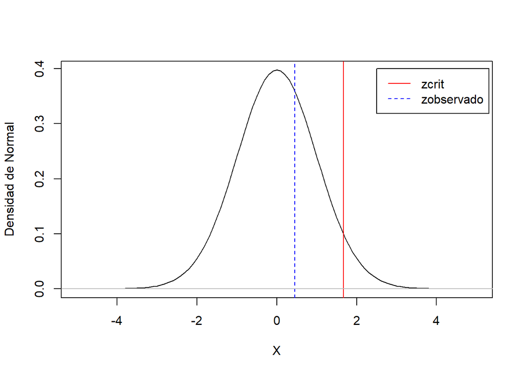

### Segunda prueba de Hipótesis:

$H_0:$ *Las personas que trabajan, tienen un promedio ponderado menor al de la media muestral*

**Justificación:**

Esta prueba de hipótesis fue elegida gracias a que el hecho de trabajar requiere mucho tiempo, por lo que se pueden descuidar los estudios e incluso las actividades recreativas. Gracias a nuestras correlaciones nos damos cuenta de que el promedio ponderado depende en gran parte de tener una cantidad de horas de estudio, las cuales ayuden a reforzar conocimientos. Escogemos nuevamente como punto de partida la media muestral del promedio ponderado, ya que nos indica en que valor se equilibraría dicha variable.

**Desarrollo:** - Datos iniciales:

```r
trab<-which(DF$`Horas de trabajo`>0)
dtrab<-DF[trab,]
n<-nrow(dtrab)
prom<-mean(dtrab$`Promedio ponderado`, na.rm=TRUE) #Media muestral
valor<-mean(DF$`Promedio ponderado`, na.rm = TRUE)
sigma<-sd(dtrab$`Promedio ponderado`, na.rm=TRUE) #Desviación estándar
```

- “Z Crítico”:

```
## [1] -1.75305
```

- Límites:

```
## [1] 14.3135
```

```
## [1] 15.7403
```

- Prueba de hipótesis:

```
## [1] -0.787
```

```
## [1] 0.2218
```

-*Gráfica(Unilateral izquierda):*

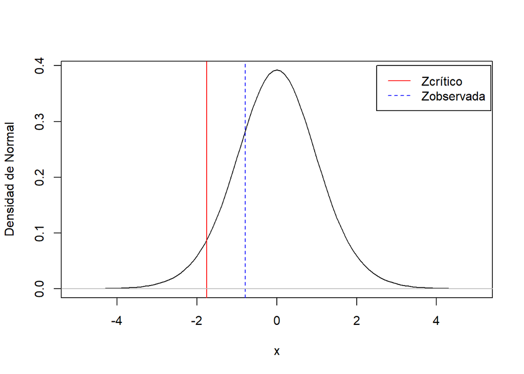

### Tercera prueba de Hipótesis:

$H_0:$ *Las personas que llevan menos de 6 cursos en el semestre, tienen un promedio ponderado mayor al de la media muestral*

$H_1:$ *Las personas que llevan menos de 6 cursos en el semestre, tienen un promedio ponderado menor al de la media muestral*

**Justificación:**

La siguiente prueba de hipótesis esta basada en el hecho de que al llevar menos cantidad de cursos, las personas son capaces de dedicar más tiempo a estudiar y a actividades recreativas, los cuales son dos factores capaces de lograr hacer que el promedio ponderado de los estudiante sea mayor. Escogemos que sea menor a 6 cursos debido a que es un aproximado al valor de la mediana conseguido en los descriptores numéricos. De forma similar a las pruebas anteriores, escogeremos como valor del promedio ponderado, el dado por la media muestral, debido a que compararemos los resultados con este.

**Desarrollo:** - Datos iniciales:

- “Z Crítico”:

```
## [1] -1.662155
```

- Límites:

```
## [1] 14.8893
```

```
## [1] 15.45
```

- Prueba de hipótesis:

```
## [1] -1.0522
```

```
## [1] 0.1478
```

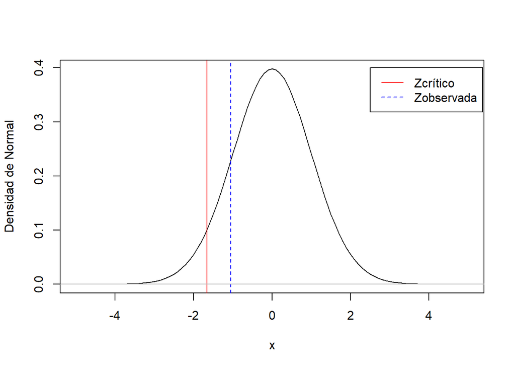

## *Análisis Predictivo*

### Regresión #1

```
##
## Call:
## lm(formula = DF$`Cantidad de horas de clases a la semana` ~ DF$`Cantidad de cursos en el semestre`)
##
## Residuals:
##      Min       1Q   Median       3Q      Max
## -14.2832  -3.0307  -0.7781   2.9062  26.4744
##
## Coefficients:
##                                        Estimate Std. Error t value Pr(>|t|)
## (Intercept)                              4.7680     2.1468   2.221   0.0284 *
## DF$`Cantidad de cursos en el semestre`   3.2525     0.3842   8.465 1.39e-13 ***
## ---
## Signif. codes:  0 '***' 0.001 '**' 0.01 '*' 0.05 '.' 0.1 ' ' 1
##
## Residual standard error: 4.879 on 108 degrees of freedom
## Multiple R-squared:  0.3989, Adjusted R-squared:  0.3933
## F-statistic: 71.66 on 1 and 108 DF,  p-value: 1.39e-13
```

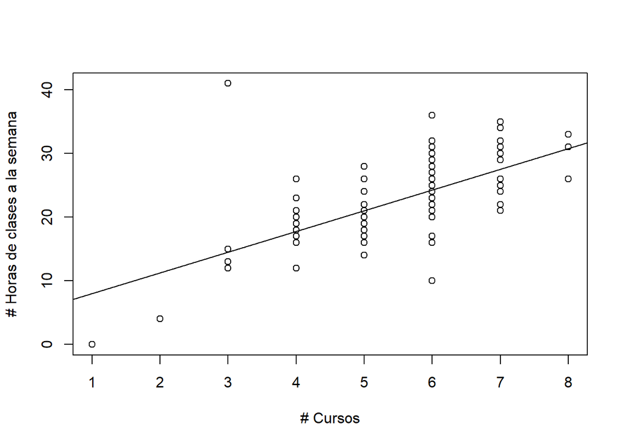

Para determinar la ecuación correspondiente a esta regresión, primero debemos interpretar nuestas variables dependientes e independientes:

$$Variable\ dependiente: Horas\ de \ clases\ a \ la \ semana$$
$$Variable\ independiente: Cantidad \ de \ Cursos$$
Respecto a dichas variables y los datos encontrados en nuestro summary, podemos llegar a la siguiente ecuación:

- Horas de clase a la semana $\approx$ 3.2525* cursos en el semestre + 4.7680

#### Análisis:

- *Coeficientes*:
  - Intercepto: Para una significancia de 0.1, la cual fue escogida para estos análisis, el intercepto toma el valor de 4.7680, esto indica el corte con el eje de ordenadas, lo cual hace que se rechace la $H0$ de que $b=0$. Esto representa que a la cantidad de 0 cursos, llevarían 4.7680 horas de clase, lo cual teóricamente no debería ser así, sin embargo, al estar nuestros datos muy dispersos y presentar un $R^2$ relativamente bajo, indican la poca relación que tienen dichas variables y el error que presenta.
  - Pendiente: Para una significancia de 0.1, nos sale que el valor de la pendiente es 3.2525, lo cual hace que se rechace la $H0$ de que $m=0$. Esto representa que llevando diferente cantidad de cursos, las horas de clase varían, pues cada curso tiene una duración establecida, lo cual hace razonable dicha prueba.
  - $R^2$: Para este caso, el coeficiente de determinación nos da un valor de 0.3989, lo cual representa la poca correlación de nuestras variables.
  - Pvalor: Para una significancia de 0.1, con una valor de $1.39e-13$ se rechaza la $H0$ de que el modelo no explica nada, lo cual indica que nuestra regresión intenta encontrar alguna explicación sobre el por qué de la relación (mínima) de dichas variables.

#### Predicción:

Para corroborar el ajuste hecho, utilizaremos los datos del alumno identificado con código: 202010209, el cual no participó en el estudio.

$$Número\ de\ cursos\ matriculados:\ 6$$
$$Hora\ de\ clases\ reales: \ 24$$
$$Horas\ de\ clases\ con\ la \ predicción:$$

```
## [1] 24
```

De acuerdo al modelo de regresión el valor de la cantidad de horas de clase a la semana debería ser 24, por lo que cumple con el ajuste propuesto inicialmente. Esto se debe a que, pese a su baja correlación, la cantidad de cursos es un aproximado de la mediana, al igual que la cantidad de horas de clase, lo cual está dentro de la tendencia central de nuestra variable.

#### Requisitos de la linealidad:

- Linealidad

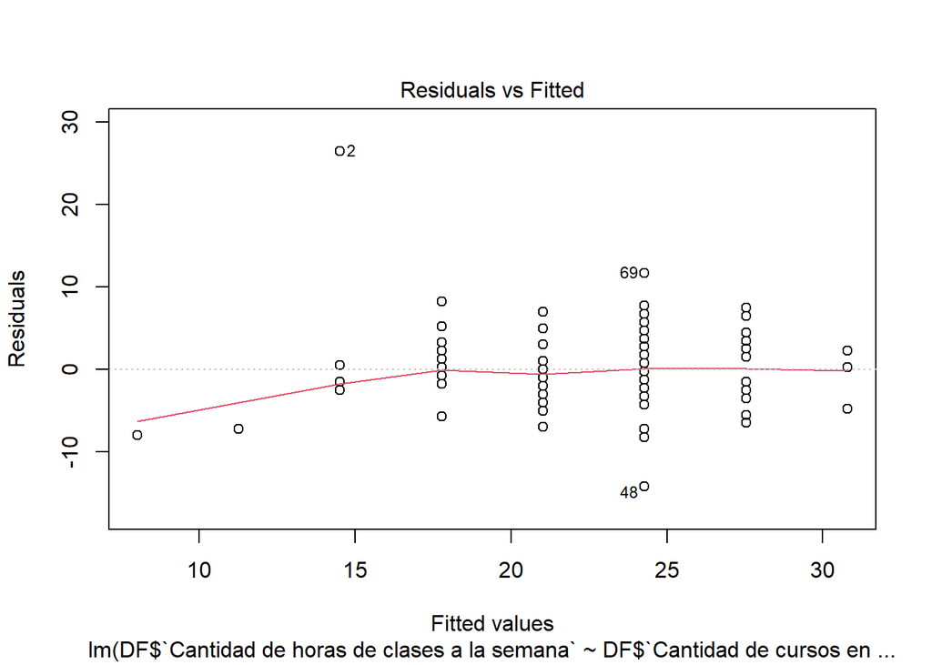

- Normalidad de residuos

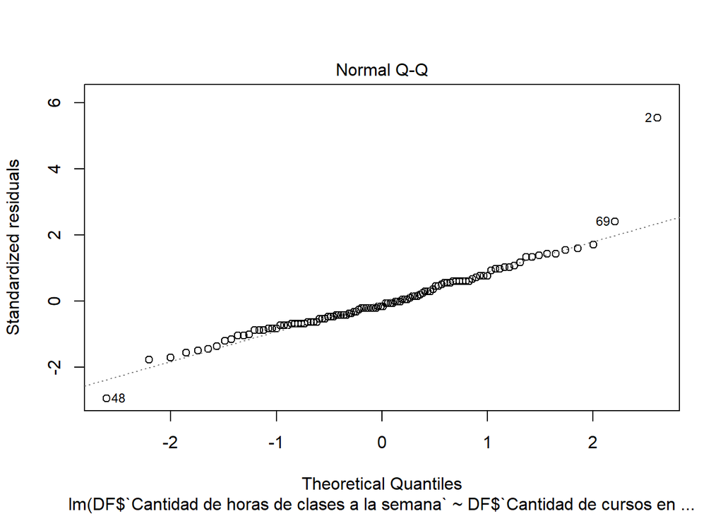

Debido a que nuestra gráfica presenta datos fuera de la linea, podemos suponer que no tiene una distribución normal. Usando el test de Shapiro, teniendo un pvalor de $2.194e-06$ confirmamos que no cumple con una distribución normal.

- Homocedasticidad

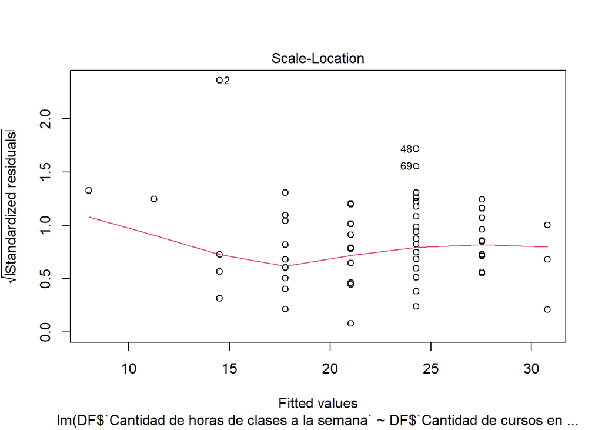

Debido a que en el gráfico no se distingue la linea horizontal, podemos concluir de que el modelo es heterocedástico. Teniendo un pvalor de $0.00025737$ con el test de Breusch Pagan, podemos corroborar que es un modelo heterocedástico.

### Regresión #2:

```
##
## Call:
## lm(formula = Datos3$`Promedio ponderado` ~ Datos3$`Cantidad de horas dedicadas a las actividades recreativas`)
##
## Residuals:
##     Min      1Q  Median      3Q     Max
## -3.5373 -1.1643  0.1661  1.1095  2.6153
##
## Coefficients:
##                                                                    Estimate
## (Intercept)                                                        15.29706
## Datos3$`Cantidad de horas dedicadas a las actividades recreativas` -0.02664
##                                                                    Std. Error
## (Intercept)                                                           0.21109
## Datos3$`Cantidad de horas dedicadas a las actividades recreativas`    0.01416
##                                                                    t value
## (Intercept)                                                         72.466
## Datos3$`Cantidad de horas dedicadas a las actividades recreativas`  -1.881
##                                                                    Pr(>|t|)
## (Intercept)                                                          <2e-16 ***
## Datos3$`Cantidad de horas dedicadas a las actividades recreativas`   0.0632 .
## ---
## Signif. codes:  0 '***' 0.001 '**' 0.01 '*' 0.05 '.' 0.1 ' ' 1
##
## Residual standard error: 1.322 on 91 degrees of freedom
## Multiple R-squared:  0.03741,    Adjusted R-squared:  0.02684
## F-statistic: 3.537 on 1 and 91 DF,  p-value: 0.06321
```

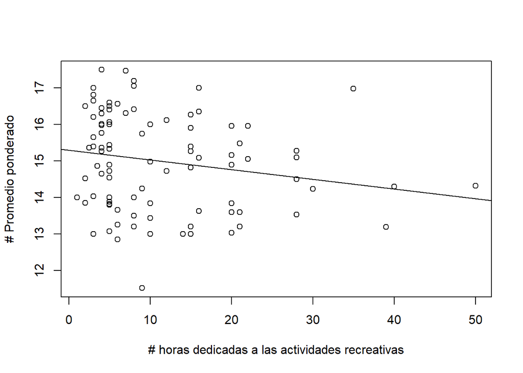

Para determinar la ecuación correspondiente a esta regresión, primero debemos interpretar nuestas variables dependientes e independientes:

$$Variable\ dependiente: Promedio \ Ponderado$$
$$Variable\ independiente: Horas\ dedicadas\ a\ las\ actividades\ recreativas$$

Gracias a la identificación de dichas variables, pudimos llegar a la siguiente ecuación:

- Promedio ponderado $\approx$ - 0.02664* Cantidad de horas dedicadas a las actividades recreativas + 15.29706

#### Análisis:

- *Coeficientes*:
  - Intercepto: Para una significancia de 0.1, el intercepto toma el valor de 15.29706, lo cual indica el valor de $Y$ cuando $x=0$, con esto concluimos que se rechaza la $H0$ de que $b=0$, lo cual indica que al no dedicar tiempo a las actividades recreativas, el promedio ponderado sería $15.29706$, el cual es un valor cercano al de la media.
  - Pendiente: Para una significancia de 0.1, la pendiente presenta el valor de -0.02664, con los cual se rechaza la $H0$ de que $m=0$. Esto nos indica que el promedio no se mantiene constante en los alumnos dependiendo de las horas que se dedican a sus actividades recreativas, mas bien presentan una pendiente negativa, lo cual indica que mientras más tiempo se recreen o distraigan, su promedio irá bajando, lo cual nos haría replantear la importancia de estas.
  - $R^2$: El coeficiente de determinación obtenido de esta regresión, obtiene el valor de $0.03741$, lo cual indica una poca correlación entre ambas variables.
  - Pvalor: Para una significancia de 0.1, nuestro valor toma el valor de $0.06321$, con el cual se rechaza la $H0$ de que el modelo no explica nada. Lo que nuestro modelo trataría de explicar sería la variación negativa del promedio ponderado, lo cual es perjudicial en los alumnos.

#### Requisitos de la linealidad:

- Linealidad:

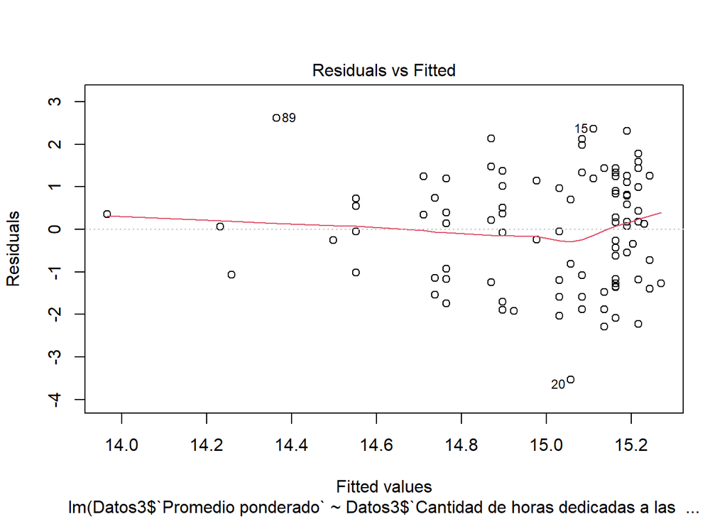

Gracias a la gráfica notar que no se cumple con la linealidad requerida, esto debido a que la linea roja no se encuentra a la altura de la linea punteada. Del mismo modo, usando el test de correlación, nos damos cuenta que el pvalor es de $0.3513$, con lo cual podemos confirmar de que nuestro modelo no es lineal.

- Normalidad de residuos:

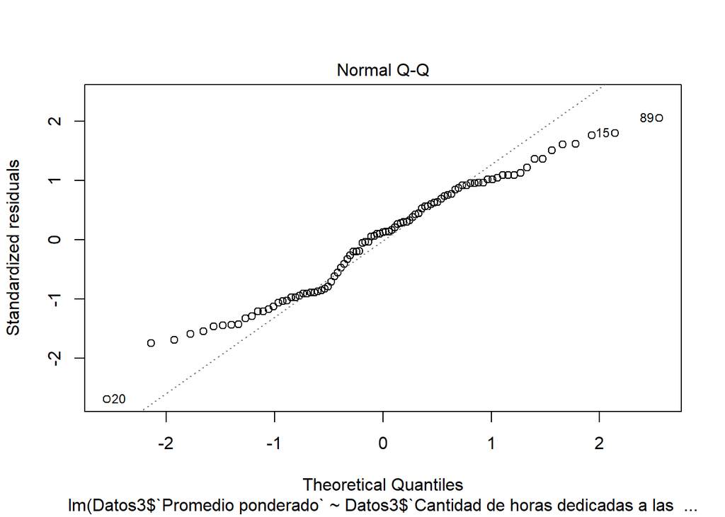

Debido a que tiene algunos datos dispersos (fuera de la linea) podemos suponer que no tiene una distribución normal. Realizando un test de Shapiro, tenemos un pvalor de $0.02972$ que nos muestra que los residuales no tiene una distribución normal.

- Homocedasticidad:

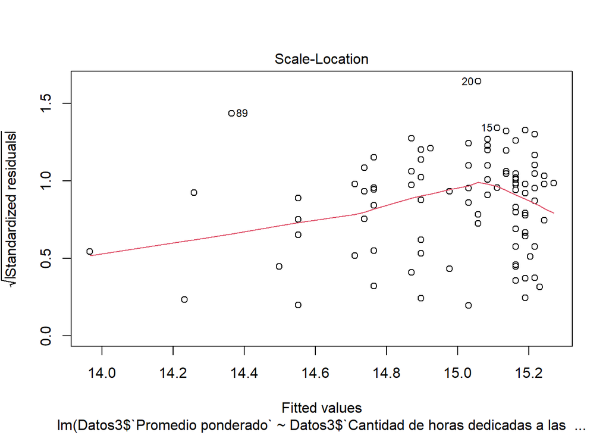

Debido a que en el gráfico no se distingue la linea horizontal, podemos concluir de que el modelo es heterocedástico. Al mismo tiempo los datos no están concentrados alrededor de la recta, reforzando la idea mencionada anteriormente.

### Regresión #3:

```
##
## Call:
## lm(formula = Datos3$`Promedio ponderado` ~ Datos3$`Cantidad de horas dedicadas a las actividades recreativas` +
##     Datos3$`Importancia de realizar A.R.`)
##
## Residuals:
##    Min     1Q Median     3Q    Max
## -3.686 -1.106  0.153  1.064  2.514
##
## Coefficients:
##                                                                    Estimate
## (Intercept)                                                        14.30727
## Datos3$`Cantidad de horas dedicadas a las actividades recreativas` -0.02846
## Datos3$`Importancia de realizar A.R.`                               0.23089
##                                                                    Std. Error
## (Intercept)                                                           0.80173
## Datos3$`Cantidad de horas dedicadas a las actividades recreativas`    0.01419
## Datos3$`Importancia de realizar A.R.`                                 0.18047
##                                                                    t value
## (Intercept)                                                         17.845
## Datos3$`Cantidad de horas dedicadas a las actividades recreativas`  -2.006
## Datos3$`Importancia de realizar A.R.`                                1.279
##                                                                    Pr(>|t|)
## (Intercept)                                                          <2e-16 ***
## Datos3$`Cantidad de horas dedicadas a las actividades recreativas`   0.0478 *
## Datos3$`Importancia de realizar A.R.`                                0.2040
## ---
## Signif. codes:  0 '***' 0.001 '**' 0.01 '*' 0.05 '.' 0.1 ' ' 1
##
## Residual standard error: 1.317 on 90 degrees of freedom
## Multiple R-squared:  0.05461,    Adjusted R-squared:  0.0336
## F-statistic: 2.599 on 2 and 90 DF,  p-value: 0.0799
```

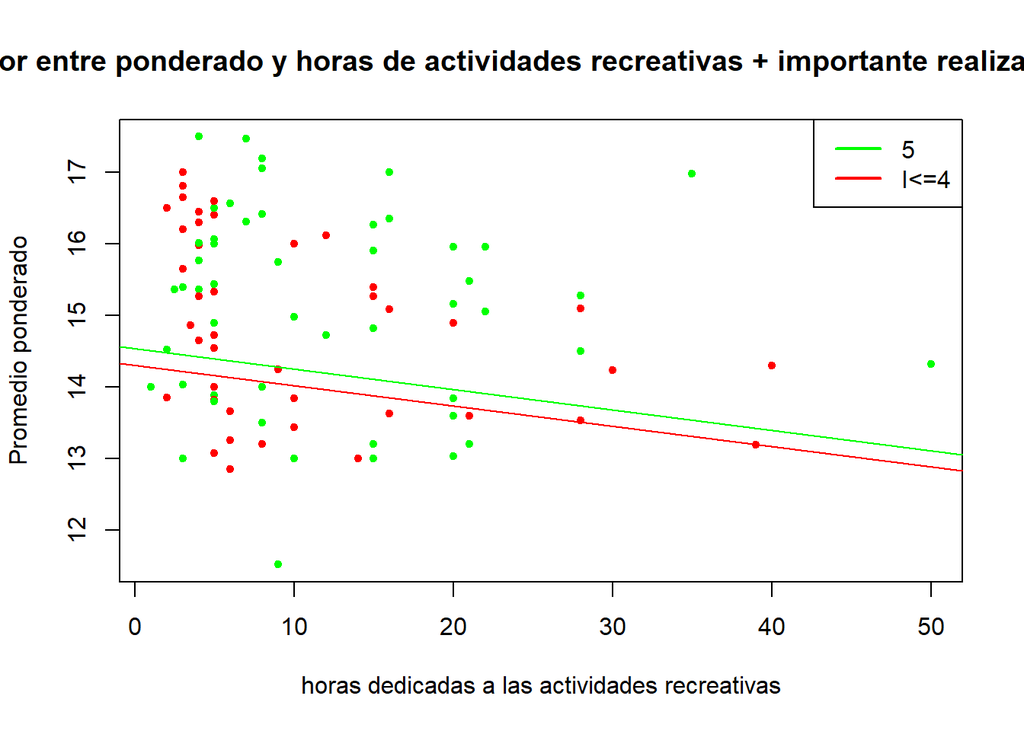

Luego de extraer algunas datos del $summar$ pudimos encontrar una variable dependiente y dos independientes:

$$Variable\ dependiente: Promedio \ Ponderado$$
$$Variable\ independiente: Importancia\ de\ realizar\ actividades\ recreativas$$
$$Variable\ independiente: Horas\ dedicadas\ a\ las\ actividades\ recreativas$$

Luego de identificar estos datos, encontramos la siguiente acuación:

- Promedio ponderado $\approx$- 0.02846* Cantidad de horas dedicadas a las actividades recreativas + 14.30727

La fórmula para determinar el promedio ponderado es:

- Promedio ponderado $\approx$ - 0.02846* Cantidad de horas dedicadas a las actividades recreativas + *0.23089(Importancia de realizar A.R.) + 14.30727